# Talent Management Solutions to Prevent Employee Attrition

Elisabet Zidow, Jonathan Franks, Shanqing Gu

4/15/2018

#### Executive Summary

In this case study of employee attrition, our Zwei Group from DDSAnalytics use the given dataset to predict the top factors that contribute to this issue and address other intersting questions realted to job trends. The GLM and Random Forrest Models have higher accuracy than Neural Network, Cart, and LASSO models for attrition prediction. The top selected variables are Over Time, Business Travel, Marital Status (Single), Job Role (Sales), Age and Monthly Income. In addtion, we find that both Research Scientists and Sales Executives tend to have better education, work mainly in life science and medical fields, and do well with their marriage and careers. Unexpectedly, we also find stock option levels are different among single, married, and divorced. This inequality may need to be improved in the future.

#### Introduction to Case Study

Employee turnover (attrition) is the reduction of staff by voluntary or involuntary reasons. This is never good for business.

Can we predict which employee is going to leave next month? Can we keep employee for longer time with a bonus program or promotion? Our DDSAnalytics is specialized in providing talent management solutions to these questions

With the given data (1,470 observations and 35 variables), we have identified answers to the following questions: (1) What are the top factors that contribute to turnover? (2) How about the job role specific trends? (3) What about other interesting trends and observations?

#### Libraries used for Case Study

```r
library(ggplot2)
library(caret)
library(plyr)
library(dplyr)
library(visreg)
library(glmnet)
library(rpart)
library(randomForest)
library(nnet)
library(devtools)
library(rpart.plot)
library(caret)
library(neuralnet)
```

#### Get access to CaseStudy2.csv data

```r
cs2 <- read.csv("/Users/shanqinggu/Desktop/CaseStudy2.csv")
apply(cs2,2,function(x) sum(is.na(x))) # check missing data
```

```
##                      Age                Attrition           BusinessTravel
##                        0                        0                        0
##                DailyRate               Department         DistanceFromHome
##                        0                        0                        0
##                Education           EducationField            EmployeeCount
##                        0                        0                        0
##           EmployeeNumber  EnvironmentSatisfaction                   Gender
##                        0                        0                        0
##               HourlyRate           JobInvolvement                 JobLevel
##                        0                        0                        0
##                  JobRole          JobSatisfaction            MaritalStatus
##                        0                        0                        0
##            MonthlyIncome              MonthlyRate       NumCompaniesWorked
##                        0                        0                        0
##                   Over18                 OverTime        PercentSalaryHike
##                        0                        0                        0
##        PerformanceRating RelationshipSatisfaction            StandardHours
##                        0                        0                        0
##         StockOptionLevel        TotalWorkingYears    TrainingTimesLastYear
##                        0                        0                        0
##          WorkLifeBalance           YearsAtCompany       YearsInCurrentRole
##                        0                        0                        0
##  YearsSinceLastPromotion     YearsWithCurrManager
##                        0                        0
```

```r
str(cs2)
```

```
## 'data.frame':    1470 obs. of  35 variables:
##  $ Age                     : int  41 49 37 33 27 32 59 30 38 36 ...
##  $ Attrition               : Factor w/ 2 levels "No","Yes": 2 1 2 1 1 1 1 1 1 1 ...
##  $ BusinessTravel          : Factor w/ 3 levels "Non-Travel","Travel_Frequently",..: 3 2 3 2 3 2 3 3 2 3 ...
##  $ DailyRate               : int  1102 279 1373 1392 591 1005 1324 1358 216 1299 ...
##  $ Department              : Factor w/ 3 levels "Human Resources",..: 3 2 2 2 2 2 2 2 2 2 ...
##  $ DistanceFromHome        : int  1 8 2 3 2 2 3 24 23 27 ...
##  $ Education               : int  2 1 2 4 1 2 3 1 3 3 ...
##  $ EducationField          : Factor w/ 6 levels "Human Resources",..: 2 2 5 2 4 2 4 2 2 4 ...
##  $ EmployeeCount           : int  1 1 1 1 1 1 1 1 1 1 ...
##  $ EmployeeNumber          : int  1 2 4 5 7 8 10 11 12 13 ...
##  $ EnvironmentSatisfaction : int  2 3 4 4 1 4 3 4 4 3 ...
##  $ Gender                  : Factor w/ 2 levels "Female","Male": 1 2 2 1 2 2 1 2 2 2 ...
##  $ HourlyRate              : int  94 61 92 56 40 79 81 67 44 94 ...
##  $ JobInvolvement          : int  3 2 2 3 3 3 4 3 2 3 ...
```

[output cut: 21 more lines]

#### Exploratory Data Analysis

```r
nearZeroVar(cs2)
```

```
## [1]  9 22 27
```

```r
head(cs2[9])
```

```
##   EmployeeCount
## 1             1
## 2             1
## 3             1
## 4             1
## 5             1
## 6             1
```

```r
head(cs2[22])
```

```
##   Over18
## 1      Y
## 2      Y
## 3      Y
## 4      Y
## 5      Y
## 6      Y
```

```r
head(cs2[27])
```

```
##   StandardHours
## 1            80
## 2            80
## 3            80
## 4            80
## 5            80
## 6            80
```

```r
# These features with no variation are Over18, EmployeeCount and StandardHours
# We will drop these fields
# Additionally, EmployeeNumber is an integer but with no meaning for modeling
# We'll null it out as well, so that it doesn't negatively impact the model

cs2$Over18 <- NULL
cs2$EmployeeCount <- NULL
cs2$StandardHours <- NULL
cs2$EmployeeNumber <- NULL
```

#### OverTime is a likely candidate for driving attrition

```r
table(cs2$Attrition)
```

```
##
##   No  Yes
## 1233  237
```

```r
# Calculation the frequencies
prop.table(table(cs2$OverTime))
```

```
##
##        No       Yes
## 0.7170068 0.2829932
```

```r
# Calculate frequencies with ddply
Overtime_per<- ddply(cs2,.(Attrition),
    function(x) with(x,
      data.frame(100*round(table(OverTime)/length(OverTime),2))))
head(Overtime_per)
```

```
##   Attrition OverTime Freq
## 1        No       No   77
## 2        No      Yes   23
## 3       Yes       No   46
## 4       Yes      Yes   54
```

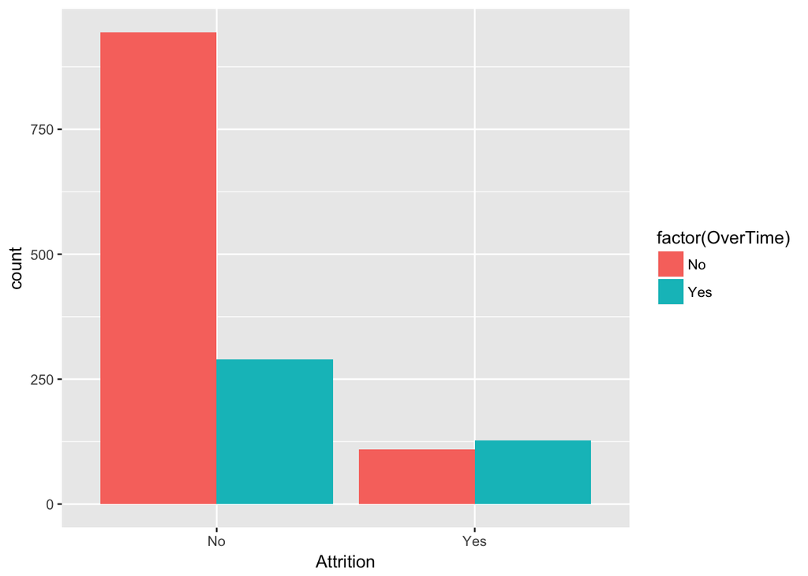

```r
# Plot categorical values against Attrition
  ggplot(cs2, aes(Attrition, ..count.., fill = factor(OverTime))) + geom_bar(position="dodge")
```

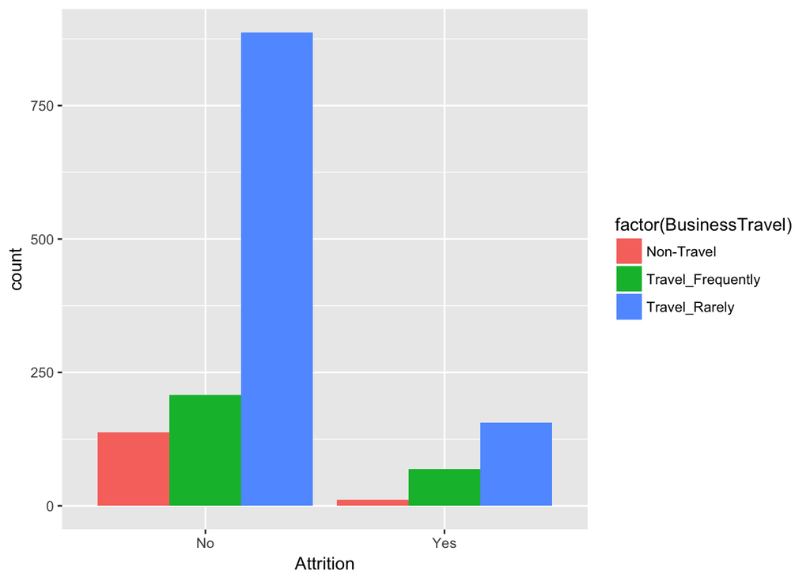

```r
  ggplot(cs2, aes(Attrition, ..count.., fill = factor(BusinessTravel))) + geom_bar(position="dodge")
```

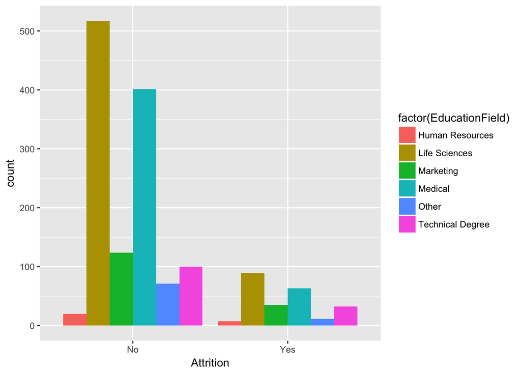

```r
  ggplot(cs2, aes(Attrition, ..count.., fill = factor(EducationField))) + geom_bar(position="dodge")
```

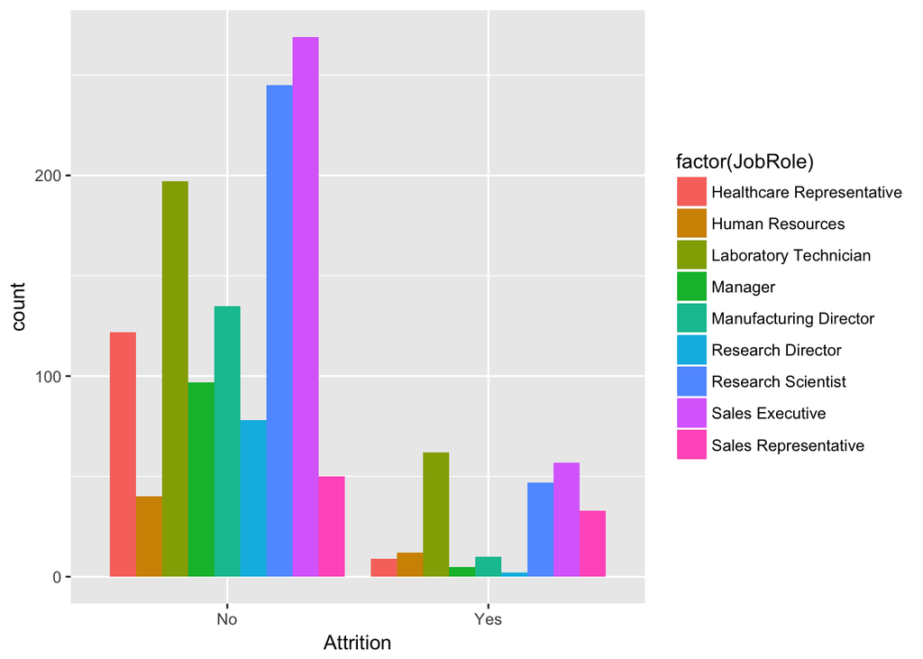

```r
  ggplot(cs2, aes(Attrition, ..count.., fill = factor(JobRole))) + geom_bar(position="dodge")
```

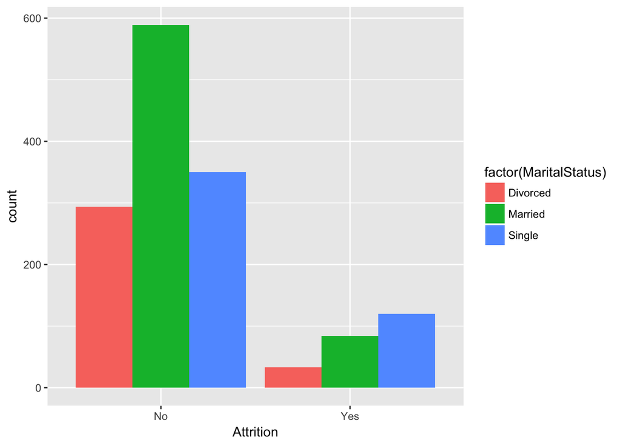

```r
  ggplot(cs2, aes(Attrition, ..count.., fill = factor(MaritalStatus))) + geom_bar(position="dodge")
```

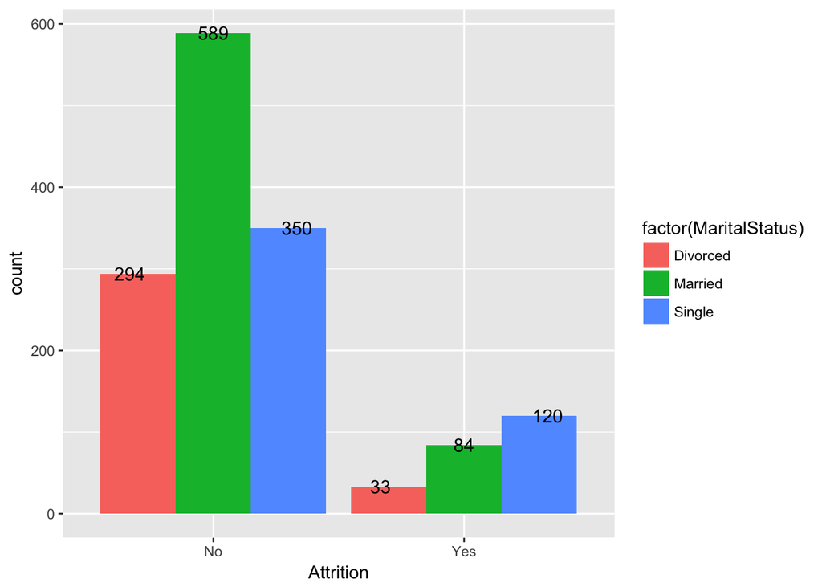

```r
  ggplot(cs2, aes(Attrition, ..count.., fill = factor(MaritalStatus))) + geom_bar(position="dodge") + geom_text(stat='count', aes(label= ..count.., group=MaritalStatus), position=position_dodge(width=1), size=4)
```

```r
OverTime_per<- ddply(cs2,.(Attrition),
    function(x) with(x,
      data.frame(100*round(table(OverTime)/length(OverTime),2))))
print(OverTime_per)
```

```
##   Attrition OverTime Freq
## 1        No       No   77
## 2        No      Yes   23
## 3       Yes       No   46
## 4       Yes      Yes   54
```

```r
BizTravel_per<- ddply(cs2,.(Attrition),
    function(x) with(x,
      data.frame(100*round(table(BusinessTravel)/length(BusinessTravel),2))))
print(BizTravel_per)
```

```
##   Attrition    BusinessTravel Freq
## 1        No        Non-Travel   11
## 2        No Travel_Frequently   17
## 3        No     Travel_Rarely   72
## 4       Yes        Non-Travel    5
## 5       Yes Travel_Frequently   29
## 6       Yes     Travel_Rarely   66
```

```r
Ed_per<- ddply(cs2,.(Attrition),
    function(x) with(x,
      data.frame(100*round(table(EducationField)/length(EducationField),2))))
print(Ed_per)
```

```
##    Attrition   EducationField Freq
## 1         No  Human Resources    2
## 2         No    Life Sciences   42
## 3         No        Marketing   10
## 4         No          Medical   33
## 5         No            Other    6
## 6         No Technical Degree    8
## 7        Yes  Human Resources    3
## 8        Yes    Life Sciences   38
## 9        Yes        Marketing   15
## 10       Yes          Medical   27
## 11       Yes            Other    5
## 12       Yes Technical Degree   14
```

```r
JobRole_per<- ddply(cs2,.(Attrition),
    function(x) with(x,
      data.frame(100*round(table(JobRole)/length(JobRole),2))))
print(JobRole_per)
```

```
##    Attrition                   JobRole Freq
## 1         No Healthcare Representative   10
## 2         No           Human Resources    3
## 3         No     Laboratory Technician   16
## 4         No                   Manager    8
## 5         No    Manufacturing Director   11
## 6         No         Research Director    6
## 7         No        Research Scientist   20
## 8         No           Sales Executive   22
## 9         No      Sales Representative    4
## 10       Yes Healthcare Representative    4
## 11       Yes           Human Resources    5
## 12       Yes     Laboratory Technician   26
## 13       Yes                   Manager    2
## 14       Yes    Manufacturing Director    4
## 15       Yes         Research Director    1
## 16       Yes        Research Scientist   20
## 17       Yes           Sales Executive   24
## 18       Yes      Sales Representative   14
```

```r
Marriage_per<- ddply(cs2,.(Attrition),
    function(x) with(x,
      data.frame(100*round(table(MaritalStatus)/length(MaritalStatus),2))))
print(Marriage_per)
```

```
##   Attrition MaritalStatus Freq
## 1        No      Divorced   24
## 2        No       Married   48
## 3        No        Single   28
## 4       Yes      Divorced   14
## 5       Yes       Married   35
## 6       Yes        Single   51
```

```r
summary(cs2$MonthlyIncome)
```

```
##    Min. 1st Qu.  Median    Mean 3rd Qu.    Max.
##    1009    2911    4919    6503    8379   19999
```

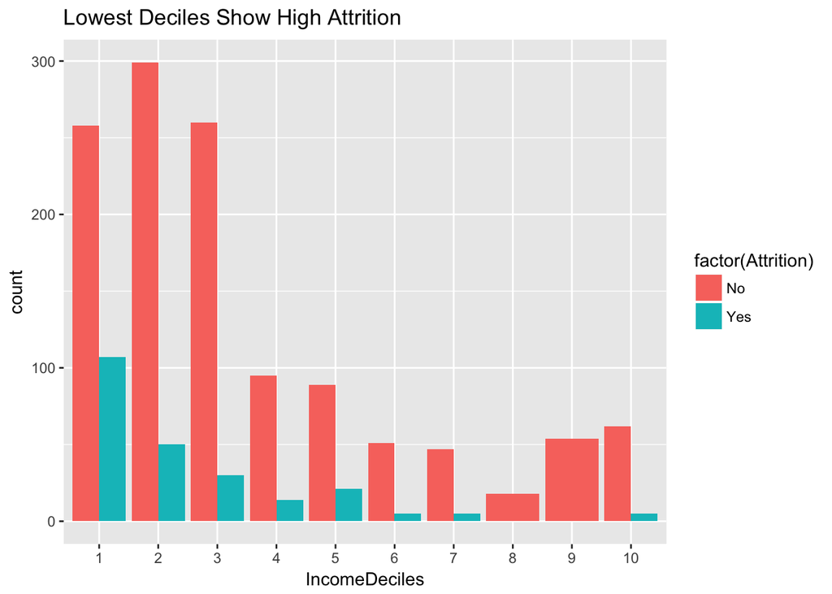

```r
# Cut income into decile groups
IncomeDeciles <- cut(cs2$MonthlyIncome, 10, include.lowest = TRUE, labels=c(1,2,3,4,5,6,7,8,9,10))

ggplot(cs2, aes(IncomeDeciles, ..count.., fill = factor(Attrition))) + geom_bar(position="dodge") + labs(title= "Lowest Deciles Show High Attrition ")
```

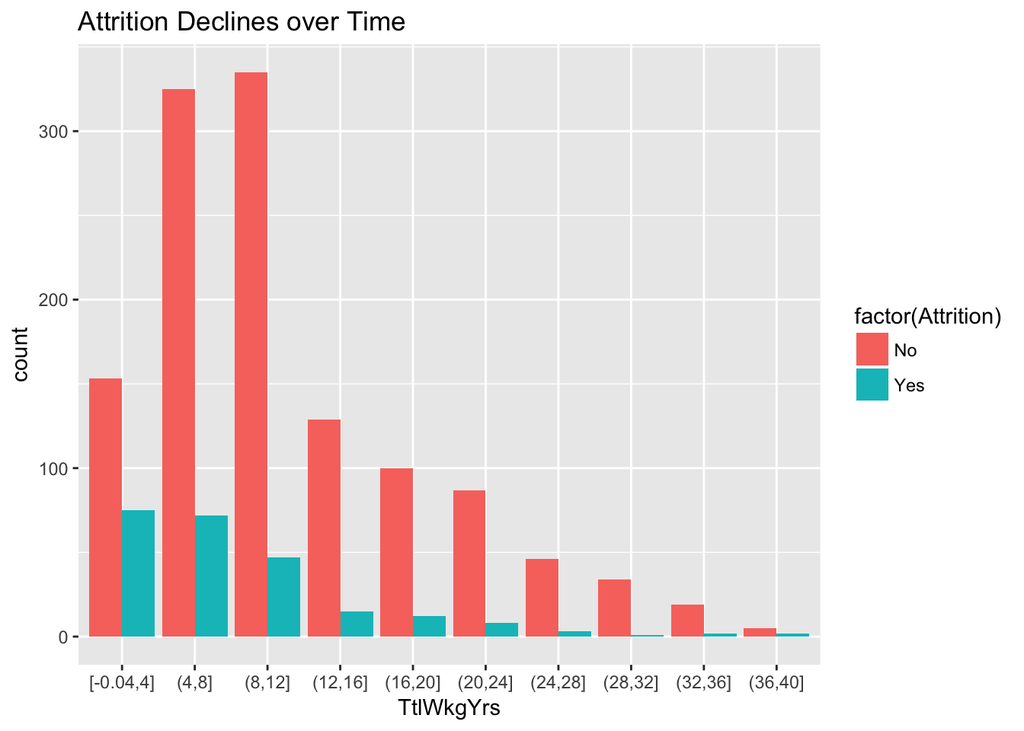

```r
TtlWkgYrs <- cut(cs2$TotalWorkingYears, 10, include.lowest = TRUE)
ggplot(cs2, aes(TtlWkgYrs, ..count.., fill = factor(Attrition))) +
labs(title= "Attrition Declines over Time") + geom_bar(position="dodge")
```

```r
cs2.glm <- glm(formula = Attrition ~., family="binomial" , data=cs2[, -c(9, 22, 27)])
cs2.glm.summary <-summary(cs2.glm)
cs2.glm.summary
```

```
##
## Call:
## glm(formula = Attrition ~ ., family = "binomial", data = cs2[,
##     -c(9, 22, 27)])
##
## Deviance Residuals:
##     Min       1Q   Median       3Q      Max
## -1.5834  -0.5086  -0.2736  -0.1060   3.4923
##
## Coefficients:
##                                    Estimate Std. Error z value Pr(>|z|)
## (Intercept)                      -1.245e+01  4.032e+02  -0.031 0.975357
## Age                              -3.057e-02  1.330e-02  -2.299 0.021490
## BusinessTravelTravel_Frequently   1.788e+00  4.030e-01   4.436 9.15e-06
## BusinessTravelTravel_Rarely       9.560e-01  3.733e-01   2.561 0.010443
## DailyRate                        -2.649e-04  2.146e-04  -1.234 0.217112
## DepartmentResearch & Development  1.282e+01  4.032e+02   0.032 0.974628
## DepartmentSales                   1.267e+01  4.032e+02   0.031 0.974927
## DistanceFromHome                  4.280e-02  1.054e-02   4.061 4.89e-05
## Education                         2.268e-02  8.592e-02   0.264 0.791805
## EducationFieldLife Sciences      -6.951e-01  7.727e-01  -0.900 0.368355
## EducationFieldMarketing          -3.282e-01  8.215e-01  -0.400 0.689486
## EducationFieldMedical            -8.101e-01  7.724e-01  -1.049 0.294237
## EducationFieldOther              -1.039e+00  8.385e-01  -1.239 0.215413
## EducationFieldTechnical Degree    4.252e-02  7.945e-01   0.054 0.957317
## GenderMale                        3.986e-01  1.801e-01   2.213 0.026909
## HourlyRate                        1.330e-03  4.321e-03   0.308 0.758303
## JobInvolvement                   -5.430e-01  1.202e-01  -4.519 6.21e-06
## JobLevel                         -1.230e-01  3.061e-01  -0.402 0.687849
## JobRoleHuman Resources            1.401e+01  4.032e+02   0.035 0.972275
## JobRoleLaboratory Technician      1.442e+00  4.723e-01   3.052 0.002271
## JobRoleManager                    3.521e-01  8.742e-01   0.403 0.687155
## JobRoleManufacturing Director     7.646e-02  5.243e-01   0.146 0.884045
## JobRoleResearch Director         -1.102e+00  1.005e+00  -1.096 0.272923
## JobRoleResearch Scientist         5.123e-01  4.837e-01   1.059 0.289559
## JobRoleSales Executive            1.167e+00  1.108e+00   1.054 0.291955
## JobRoleSales Representative       1.980e+00  1.161e+00   1.706 0.087982
## JobSatisfaction                  -3.746e-01  7.903e-02  -4.741 2.13e-06
## MaritalStatusMarried              2.976e-01  2.621e-01   1.135 0.256237
## MaritalStatusSingle               1.026e+00  3.377e-01   3.039 0.002373
```

[output cut: 51 more lines]

```
## TrainingTimesLastYear            **
## YearsAtCompany                   *
## YearsInCurrentRole               ***
## YearsSinceLastPromotion          ***
## YearsWithCurrManager             **
## ---
## Signif. codes:  0 '***' 0.001 '**' 0.01 '*' 0.05 '.' 0.1 ' ' 1
##
## (Dispersion parameter for binomial family taken to be 1)
##
##     Null deviance: 1298.58  on 1469  degrees of freedom
## Residual deviance:  896.16  on 1428  degrees of freedom
## AIC: 980.16
##
## Number of Fisher Scoring iterations: 14
```

```r
data.frame(cs2.glm.summary$coef[cs2.glm.summary$coef[,4] <= .05, 4])
```

```
##                                 cs2.glm.summary.coef.cs2.glm.summary.coef...4.....0.05..4.
## Age                                                                           2.148952e-02
## BusinessTravelTravel_Frequently                                               9.146395e-06
## BusinessTravelTravel_Rarely                                                   1.044344e-02
## DistanceFromHome                                                              4.888646e-05
## GenderMale                                                                    2.690908e-02
## JobInvolvement                                                                6.209745e-06
## JobRoleLaboratory Technician                                                  2.270880e-03
## JobSatisfaction                                                               2.131093e-06
## MaritalStatusSingle                                                           2.372928e-03
## NumCompaniesWorked                                                            7.803449e-07
## OverTimeYes                                                                   1.473160e-23
## RelationshipSatisfaction                                                      1.398958e-03
## TrainingTimesLastYear                                                         9.665190e-03
## YearsAtCompany                                                                2.164193e-02
## YearsInCurrentRole                                                            6.646071e-04
## YearsSinceLastPromotion                                                       1.866020e-04
## YearsWithCurrManager                                                          8.339881e-03
```

```r
predVal <- predict(cs2.glm, type="response") # predicted values

fitted.results.cat <- ifelse(predVal > 0.5, "Yes", "No")
fitted.results.cat <- as.factor(fitted.results.cat)

require(caret)
cm <- confusionMatrix(data=fitted.results.cat, reference = cs2$Attrition)

glmAcc <- cm$overall[1]
print(glmAcc)
```

```
##  Accuracy
## 0.8870748
```

#### List 3 top factor that contribute to turnover: BusinessTravel$Frequently, MartialStatus$Single, OverTime.

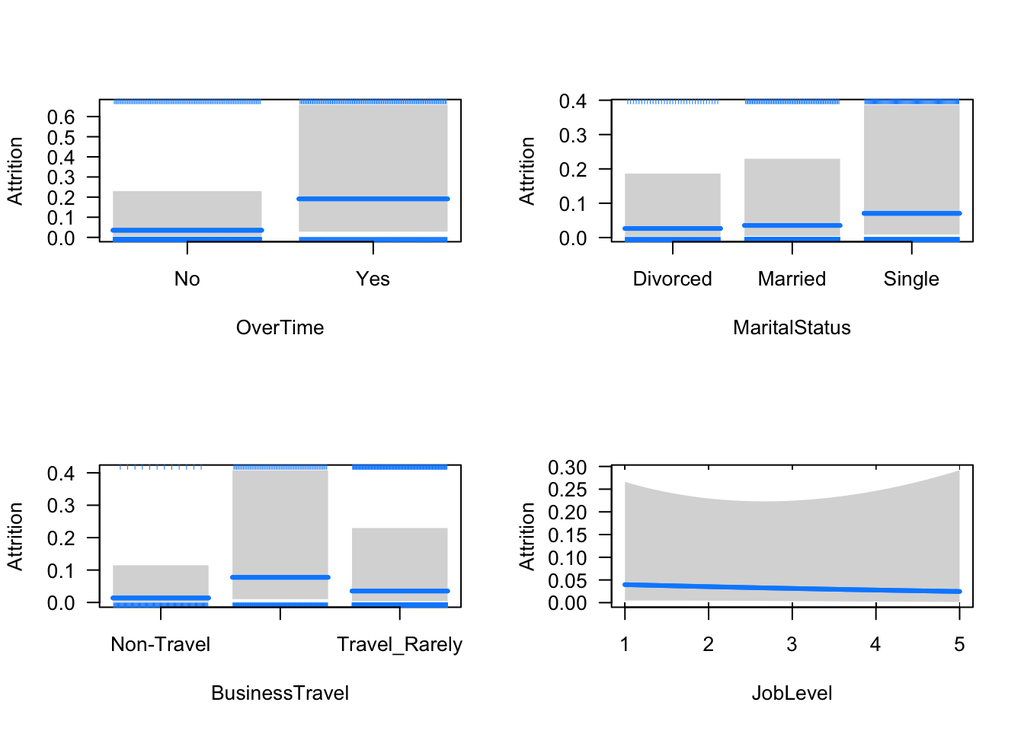

```r
par(mfrow=c(2,2))

visreg(cs2.glm, c("OverTime","MaritalStatus","BusinessTravel","JobLevel"), scale="response")
```

#### Try glmnet (lasso and elastic-net regulated generalized linear models)

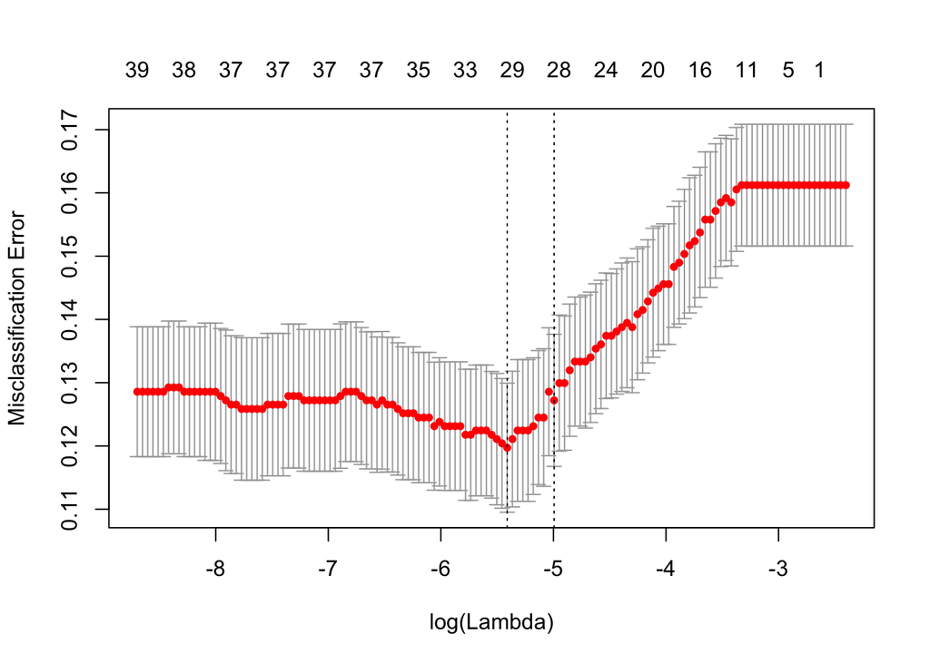

```r
 y=cs2$Attrition
 x=model.matrix(Attrition~., cs2[, -c(9, 22, 27)])

 cvfit_a <- cv.glmnet(x, y, family = "binomial", nfolds=10, type.measure = "class", nlambda=200)
 cvfit_b <- cv.glmnet(x, y, family = "binomial", nfolds=10, type.measure = "auc", nlambda=200)

 plot(cvfit_a) # show cross-validation curve (red dotted line)
```

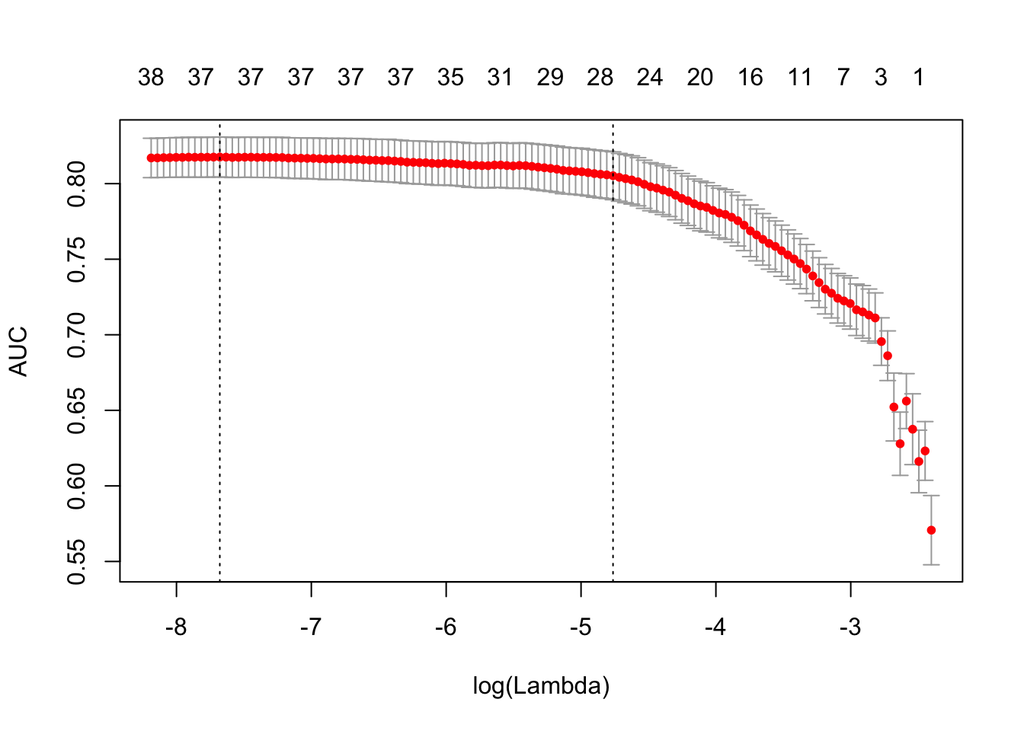

```r
 plot(cvfit_b)
```

```r
 coef(cvfit_a, s = "lambda.min")
```

```
## 43 x 1 sparse Matrix of class "dgCMatrix"
##                                              1
## (Intercept)                       1.194218e+00
## (Intercept)                       .
## Age                              -2.662778e-02
## BusinessTravelTravel_Frequently   1.006666e+00
## BusinessTravelTravel_Rarely       2.635074e-01
## DailyRate                        -1.895768e-04
## DepartmentResearch & Development -5.273993e-01
## DepartmentSales                   .
## DistanceFromHome                  3.157152e-02
## Education                         .
## EducationFieldLife Sciences       .
## EducationFieldMarketing           2.520250e-01
## EducationFieldMedical            -5.979279e-02
## EducationFieldOther              -1.934730e-01
## EducationFieldTechnical Degree    5.305393e-01
## GenderMale                        2.503308e-01
## HourlyRate                        .
## JobInvolvement                   -4.608455e-01
## JobLevel                         -1.557434e-01
## JobRoleHuman Resources            2.666691e-01
## JobRoleLaboratory Technician      7.802839e-01
## JobRoleManager                    .
## JobRoleManufacturing Director    -1.478381e-01
## JobRoleResearch Director         -4.029708e-01
## JobRoleResearch Scientist         .
## JobRoleSales Executive            .
## JobRoleSales Representative       6.334654e-01
## JobSatisfaction                  -3.001556e-01
## MaritalStatusMarried              .
## MaritalStatusSingle               6.546998e-01
## MonthlyIncome                     .
## MonthlyRate                       .
## NumCompaniesWorked                1.275630e-01
## OverTimeYes                       1.591955e+00
## PercentSalaryHike                -4.170411e-05
## RelationshipSatisfaction         -1.746499e-01
## StockOptionLevel                 -2.244527e-01
## TotalWorkingYears                -2.154758e-02
## TrainingTimesLastYear            -1.301171e-01
## YearsAtCompany                    .
## YearsInCurrentRole               -7.806429e-02
## YearsSinceLastPromotion           1.164589e-01
## YearsWithCurrManager             -5.454198e-02
```

```r
 coef(cvfit_b, s = "lambda.min")
```

```
## 43 x 1 sparse Matrix of class "dgCMatrix"
##                                              1
## (Intercept)                       2.998186e-01
## (Intercept)                       .
## Age                              -3.028453e-02
## BusinessTravelTravel_Frequently   1.683205e+00
## BusinessTravelTravel_Rarely       8.581058e-01
## DailyRate                        -2.591027e-04
## DepartmentResearch & Development  .
## DepartmentSales                   2.777588e-01
## DistanceFromHome                  4.134001e-02
## Education                         1.658453e-02
## EducationFieldLife Sciences      -3.398137e-01
## EducationFieldMarketing           1.447304e-02
## EducationFieldMedical            -4.556327e-01
## EducationFieldOther              -6.837396e-01
## EducationFieldTechnical Degree    3.569830e-01
## GenderMale                        3.801789e-01
## HourlyRate                        1.050610e-03
## JobInvolvement                   -5.360376e-01
## JobLevel                         -1.019066e-01
## JobRoleHuman Resources            1.188267e+00
## JobRoleLaboratory Technician      1.276997e+00
## JobRoleManager                    .
## JobRoleManufacturing Director    -2.394399e-02
## JobRoleResearch Director         -9.984244e-01
## JobRoleResearch Scientist         3.625796e-01
## JobRoleSales Executive            5.986934e-01
## JobRoleSales Representative       1.383498e+00
## JobSatisfaction                  -3.676869e-01
## MaritalStatusMarried              2.509961e-01
## MaritalStatusSingle               9.574427e-01
## MonthlyIncome                     .
## MonthlyRate                       1.175856e-07
## NumCompaniesWorked                1.795426e-01
## OverTimeYes                       1.829856e+00
## PercentSalaryHike                -7.628810e-03
## RelationshipSatisfaction         -2.448506e-01
## StockOptionLevel                 -2.530937e-01
## TotalWorkingYears                -4.240128e-02
## TrainingTimesLastYear            -1.787716e-01
## YearsAtCompany                    7.198290e-02
## YearsInCurrentRole               -1.394437e-01
## YearsSinceLastPromotion           1.504788e-01
## YearsWithCurrManager             -1.103179e-01
```

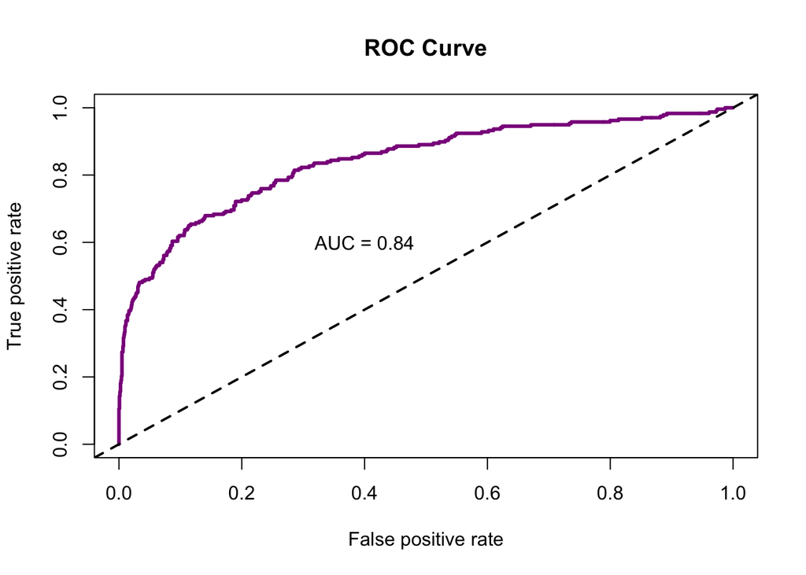

```r
 fit.pred_a <- predict(cvfit_a, newx = x, type = "response")
 fit.pred_b <- predict(cvfit_b, newx = x, type = "response")

 #Create ROC curves
 library(ROCR)
 pred <- prediction(fit.pred_b[,1], y)
 roc.perf = performance(pred, measure = "tpr", x.measure = "fpr")
 auc.perf <- performance(pred, measure = "auc")
 auc.perf <- auc.perf@y.values

 #Plot ROC
 plot(roc.perf, measure = "tpr", x.measure = "fpr", main="ROC Curve", col="darkmagenta", lwd=3)
 abline(a=0, b= 1, lwd=2, lty=2) # Ref line indicating poor performance
 text(x = .40, y = .6, paste("AUC = ", round(auc.perf[[1]],2), sep = ""))
```

### Step_07 Baseline Model

```r
table(cs2$Attrition)
```

```
##
##   No  Yes
## 1233  237
```

```r
1233/nrow(cs2)
```

```
## [1] 0.8387755
```

Assuming all cases are ‘No’ provides 83.8% accuracy.

### Create Training and Test Data Sets

```r
# Remove NA/NULL Rows to prevent contrast/factor errors in modeling
rem <- c(9,10,22,27)
dat <-cs2[,-rem]
dim(dat)
```

```
## [1] 1470   27
```

```r
indexes = sample(1:nrow(cs2), size=0.2*nrow(cs2))
test = dat[indexes,]
dim(test)
```

```
## [1] 294  27
```

```r
train = dat[-indexes,]
dim(train)
```

```
## [1] 1176   27
```

### Create Cart Model

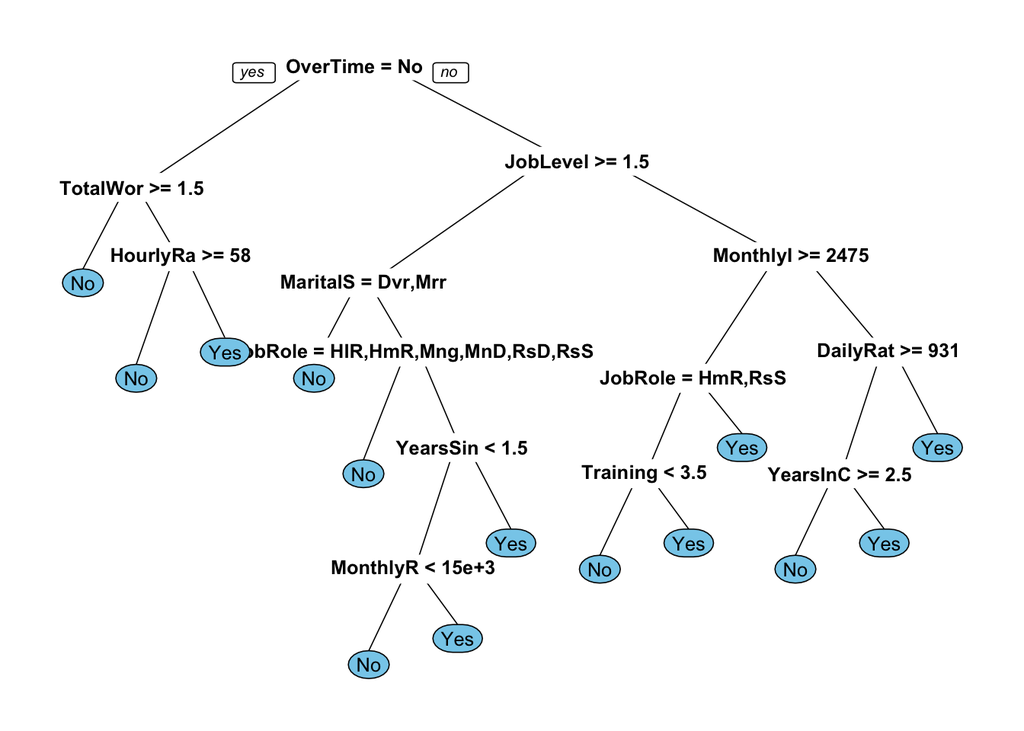

```r
modelCart = rpart(train$Attrition ~ ., data=train, method="class")
#Plot the model
prp(modelCart, box.palette = "skyblue", tweak = 1.2)
```

```r
#Predict the test data
predictionCart <- predict(modelCart, newdata=test, type="class")

#CART Accuracy
#Confusion matrix
t1 <- table(test$Attrition, predictionCart)

#CART model accuracy
(t1[1]+t1[4])/(nrow(test))
```

```
## [1] 0.8435374
```

#### Create Random Forrest Model

```r
modelRf = randomForest(Attrition ~ ., data=train, ntree = 100, mtry = 5, importance = TRUE, method="class")

# Plot the model
print(modelRf)
```

```
##
## Call:
##  randomForest(formula = Attrition ~ ., data = train, ntree = 100,      mtry = 5, importance = TRUE, method = "class")
##                Type of random forest: classification
##                      Number of trees: 100
## No. of variables tried at each split: 5
##
##         OOB estimate of  error rate: 15.05%
## Confusion matrix:
##      No Yes class.error
## No  961  20  0.02038736
## Yes 157  38  0.80512821
```

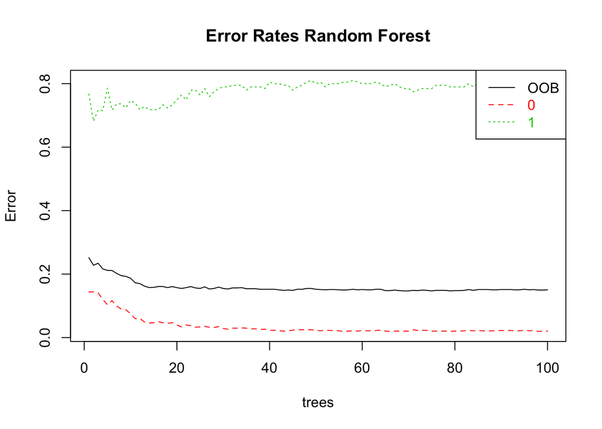

```r
#OOB vs No. Of Trees
plot(modelRf, main="")
legend("topright", c("OOB", "0", "1"), text.col=1:6, lty=1:3, col=1:3)
title(main="Error Rates Random Forest")
```

```r
## List the importance of the variables.
impVar <- round(randomForest::importance(modelRf), 2)
impVar[order(impVar[,3], decreasing=TRUE),]
```

```
##                             No   Yes MeanDecreaseAccuracy MeanDecreaseGini
## OverTime                  8.38 11.23                12.10            19.38
## StockOptionLevel          5.15  3.34                 6.22             9.24
## MonthlyIncome             4.14  3.69                 5.89            28.45
## JobRole                   4.38  1.55                 4.98            16.13
## Age                       3.92  3.23                 4.74            20.21
## JobLevel                  4.03  2.97                 4.70             7.62
## YearsAtCompany            3.73  2.47                 4.60            13.81
## TotalWorkingYears         3.81  1.73                 4.43            17.10
## BusinessTravel            2.64  2.33                 3.56             6.70
## JobSatisfaction           1.61  2.76                 2.61             9.65
## MaritalStatus             1.50  2.31                 2.44             6.54
## EducationField            1.58  1.70                 2.31            12.10
## NumCompaniesWorked        1.98  0.44                 1.93            11.11
## YearsWithCurrManager      0.37  2.38                 1.69            10.81
## JobInvolvement            1.36  0.67                 1.60             7.05
## YearsInCurrentRole        0.75  1.66                 1.57             8.32
## Department                0.99  0.74                 1.25             2.67
## Education                 1.06  0.75                 1.21             6.58
## HourlyRate                1.00  0.52                 1.15            19.29
## TrainingTimesLastYear     1.02  0.49                 1.11             8.76
## RelationshipSatisfaction  0.14  0.47                 0.32             8.92
## YearsSinceLastPromotion  -0.48  0.84                 0.05             8.32
## PercentSalaryHike        -0.09  0.23                -0.05            13.85
## MonthlyRate              -0.74  0.23                -0.44            17.17
## DailyRate                -1.56  1.82                -0.52            19.75
## DistanceFromHome         -0.10 -1.99                -1.06            15.60
```

#### Random Forest with test data

```
## mtry = 5  OOB error = 14.54%
## Searching left ...
## mtry = 3     OOB error = 14.97%
## -0.02923977 0.001
## Searching right ...
## mtry = 10    OOB error = 14.8%
## -0.01754386 0.001
```

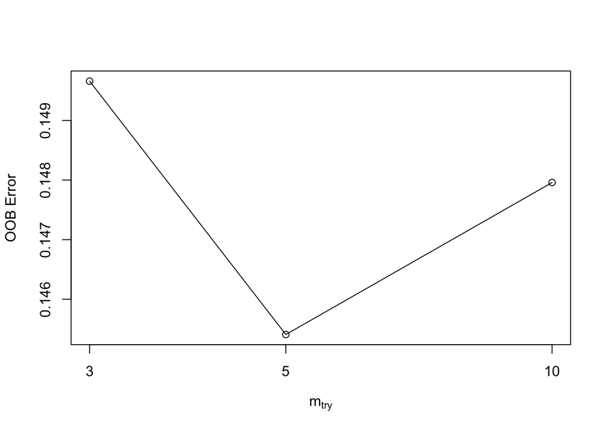

```r
## Tuning Random Forest
tunedRf <- tuneRF(x = train[,-2],
              y=as.factor(train$Attrition),
              mtryStart = 5,
              ntreeTry=60,
              stepFactor = 2,
              improve = 0.001,
              trace=TRUE,
              plot = TRUE,
              doBest = TRUE,
              nodesize = 5,
              importance=TRUE
)
```

```r
impvarTunedRf <- tunedRf$importance
impvarTunedRf[order(impvarTunedRf[,3], decreasing=TRUE),]
```

```
##                                     No           Yes MeanDecreaseAccuracy
## OverTime                  1.211065e-02  0.0462958705         0.0177808716
## MonthlyIncome             8.644844e-03  0.0168509222         0.0100911421
## JobRole                   8.877910e-03  0.0108235383         0.0091898150
## TotalWorkingYears         8.849407e-03  0.0098414796         0.0090044983
## JobLevel                  8.344326e-03  0.0103792879         0.0086764642
## Age                       7.035144e-03  0.0125619953         0.0079745340
## YearsAtCompany            5.763217e-03  0.0039482867         0.0054700879
## YearsWithCurrManager      3.181180e-03  0.0086651919         0.0040857601
## StockOptionLevel          3.480678e-03  0.0065505969         0.0040457148
## MaritalStatus             3.050240e-03  0.0048444903         0.0033176419
## YearsInCurrentRole        2.241702e-03  0.0036646812         0.0024342525
## EducationField            1.601739e-03  0.0012307519         0.0015257224
## JobSatisfaction           7.443268e-04  0.0051465139         0.0014755180
## BusinessTravel            8.292019e-04  0.0030351117         0.0011891067
## NumCompaniesWorked        1.160783e-03  0.0010107637         0.0011569011
## YearsSinceLastPromotion   1.821661e-03 -0.0026515484         0.0010722340
## HourlyRate                9.900255e-04  0.0012304754         0.0010483167
## Department                9.065540e-04  0.0008442313         0.0008866777
## DailyRate                 8.911424e-04 -0.0004503278         0.0006920321
## JobInvolvement            3.455702e-04  0.0024542740         0.0006749639
## RelationshipSatisfaction  2.106594e-04  0.0019842646         0.0005251457
## Education                 6.593772e-04 -0.0012089054         0.0003448167
## DistanceFromHome          3.079986e-04 -0.0004558077         0.0002062367
## TrainingTimesLastYear    -1.122889e-05 -0.0008386505        -0.0001478849
## MonthlyRate              -3.549643e-04 -0.0012846774        -0.0005325981
## PercentSalaryHike        -5.801297e-04 -0.0021843022        -0.0008299943
##                          MeanDecreaseGini
## OverTime                        18.852760
## MonthlyIncome                   22.900118
## JobRole                         15.470338
## TotalWorkingYears               14.372786
## JobLevel                         6.325617
## Age                             16.872480
## YearsAtCompany                  11.231298
## YearsWithCurrManager             9.334956
## StockOptionLevel                 7.646084
## MaritalStatus                    6.037229
## YearsInCurrentRole               6.399818
## EducationField                  10.740666
## JobSatisfaction                  7.099870
## BusinessTravel                   5.731228
## NumCompaniesWorked               8.948295
## YearsSinceLastPromotion          6.487723
## HourlyRate                      14.556817
## Department                       3.029744
## DailyRate                       16.005578
## JobInvolvement                   5.636938
## RelationshipSatisfaction         6.237057
## Education                        4.717076
## DistanceFromHome                11.673045
## TrainingTimesLastYear            6.529231
## MonthlyRate                     13.833993
## PercentSalaryHike                9.068133
```

```r
predictionRf <- predict(tunedRf, test, type="class")

#RandomForest Accuracy
#Confusion matrix
t2 <- table(test$Attrition, predictionRf)

#RandomForest model accuracy
(t2[1]+t2[4])/(nrow(test))
```

```
## [1] 0.877551
```

#### Martial Status Influence Factors (significant)

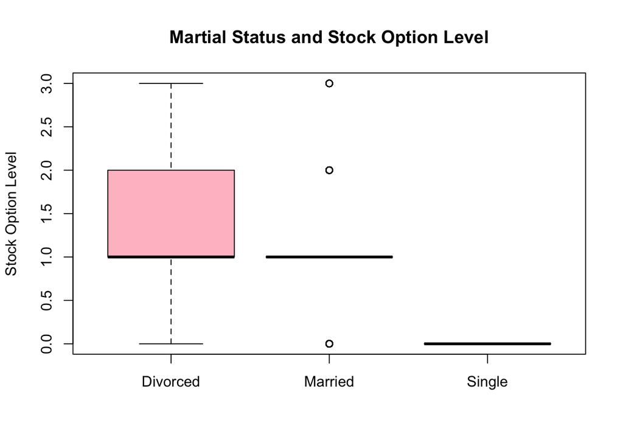

```r
# QOI_1: Martial Status Influence Factors
cs_ms.glm <- glm(formula = MaritalStatus ~., family="binomial" , data=cs2[, -c(9, 22, 27)]) # Only StockOptionLevel is significant
plot(cs2$MaritalStatus, cs2$StockOptionLevel, type="h", col="pink", lwd=1, ylab="Stock Option Level", main="Martial Status and Stock Option Level")
```

#### Job Role Trends

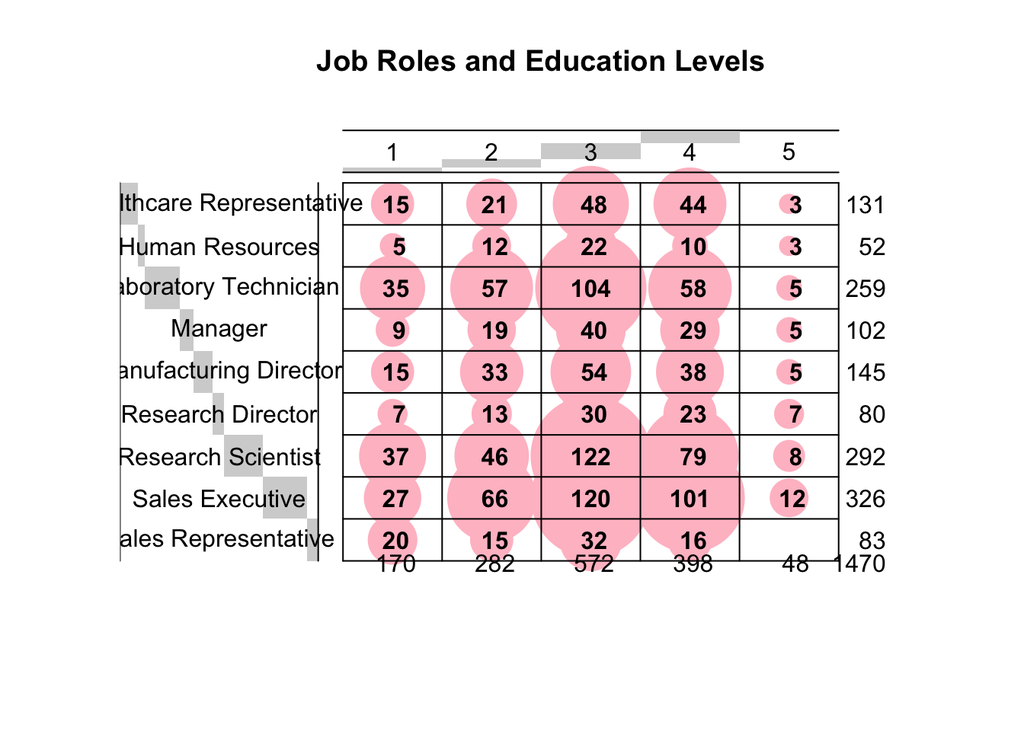

```r
# QOI_2: Job Roles and Education Levels
cs2$Education <- as.factor(cs2$Education)
dt <- table(cs2$JobRole, cs2$Education)

# chisq.test(dt)
balloonplot(t(dt), main ="Job Roles and Education Levels", xlab ="", ylab="", label = TRUE, show.margins = TRUE, dotsize=6/max(strwidth(19),strheight(19)), dotchar=19, dotcolor="pink", text.size=1, text.color=par("fg"))
```

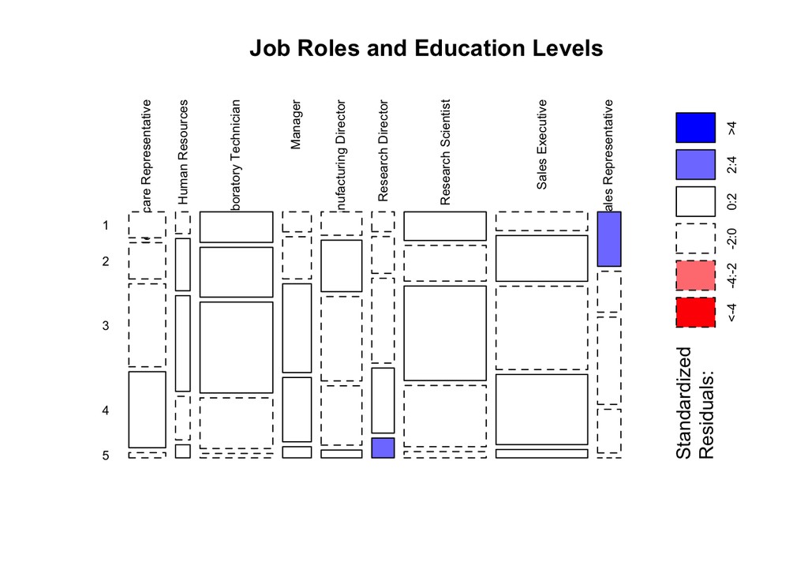

```r
library(graphics)
mosaicplot(dt, shade = TRUE, las=2, main = "Job Roles and Education Levels")
```

[figure not shown]

```r
library(vcd)
assoc(head(dt), shade = T, las=3)
```

#### J1-J6

[figure not shown]

```r
par(mfrow=c(2,2))

# J1: Job Roles and Education Levels
cs2$Education <- as.factor(cs2$Education)
dt <- table(cs2$JobRole, cs2$Education)

balloonplot(t(dt), main ="Job Roles and Education Levels", xlab ="", ylab="", label = TRUE, show.margins = TRUE, dotsize=6/max(strwidth(19),strheight(19)), dotchar=19, dotcolor="pink", text.size=1, text.color=par("fg"))

# J2: Job Roles and Departments
dt2 <- table(cs2$JobRole, cs2$Department)

balloonplot(t(dt2), main ="Job Roles and Departments", xlab ="", ylab="", label = TRUE, show.margins = TRUE, dotsize=6/max(strwidth(19),strheight(19)), dotchar=19, dotcolor="yellow", text.size=1, text.color=par("fg"))

# J3: Job Roles and Education Fields
dt3 <- table(cs2$JobRole, cs2$EducationField)

balloonplot(t(dt3), main ="Job Roles and Education Fields", xlab ="", ylab="", label = TRUE, show.margins = TRUE, dotsize=6/max(strwidth(19),strheight(19)), dotchar=19, dotcolor="cyan", text.size=1, text.color=par("fg"))

# J4: Job Roles and Job Satisfaction
dt4 <- table(cs2$JobRole, cs2$JobSatisfaction)
balloonplot(t(dt4), main ="Job Roles and Job Satisfaction", xlab ="", ylab="", label = TRUE, show.margins = TRUE, dotsize=4/max(strwidth(19),strheight(19)), dotchar=19, dotcolor="pink", text.size=1.0, text.color=par("fg"))
```

[figure not shown]

```r
# J5: Job Roles and MaritalStatus
dt5 <- table(cs2$JobRole, cs2$MaritalStatus)
balloonplot(t(dt5), main ="Job Roles and MaritalStatus", xlab ="", ylab="", label = TRUE, show.margins = TRUE, dotsize=6/max(strwidth(19),strheight(19)), dotchar=19, dotcolor="yellow", text.size=1.0, text.color=par("fg"))
```

#### J6

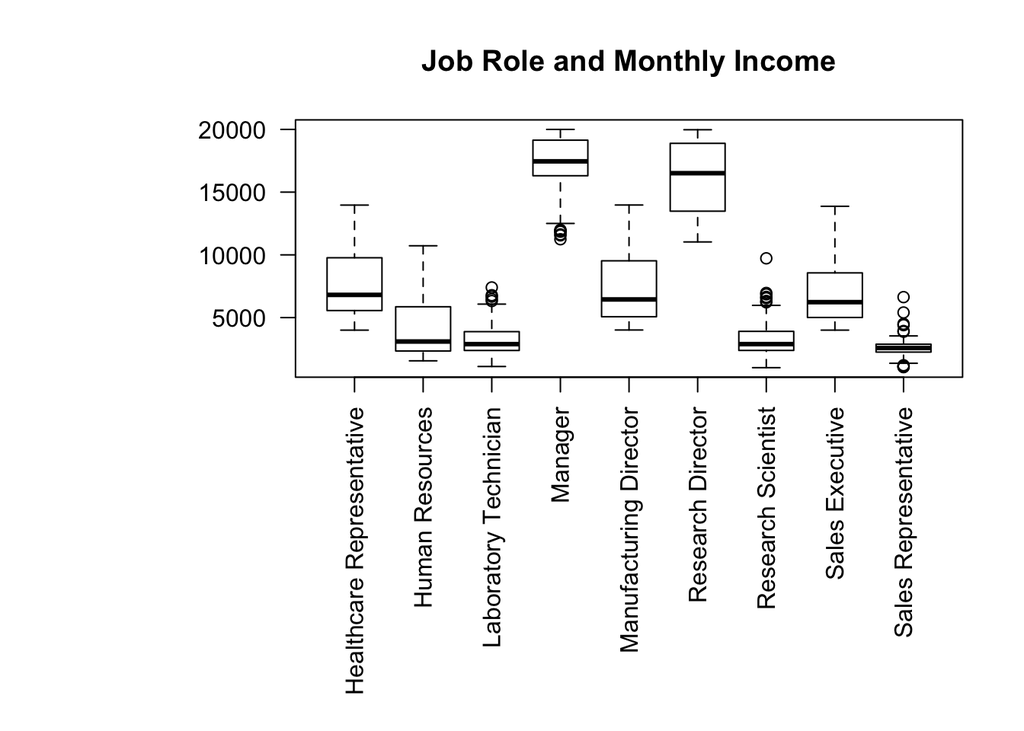

```r
# J6: Jon Role and Monthly Income
par(mar = c(12, 10, 4, 2) + 0.1)
boxplot(MonthlyIncome~JobRole,cs2,las=2, cex.axis = 1.0, horizontal=FALSE, main="Job Role and Monthly Income")
```

#### Step_nn: Neural Network Model

```r
# neural network model
# dependant variable "Attrition" as binary variable, categorical variables and numeric varialbes as independant varialbes                      # To recode each n level categorical variable to n variables with values of 1 or 0, to normalization each numeric variables to a scale between (0,1) or (-1,1);

# 1) input data;

cs<-read.csv('/Users/shanqinggu/Desktop/CaseStudy2.csv')

# 2) checking with missing value, including data review;
summary(cs)
```

```
##       Age        Attrition            BusinessTravel   DailyRate
##  Min.   :18.00   No :1233   Non-Travel       : 150   Min.   : 102.0
##  1st Qu.:30.00   Yes: 237   Travel_Frequently: 277   1st Qu.: 465.0
##  Median :36.00              Travel_Rarely    :1043   Median : 802.0
##  Mean   :36.92                                       Mean   : 802.5
##  3rd Qu.:43.00                                       3rd Qu.:1157.0
##  Max.   :60.00                                       Max.   :1499.0
##
##                   Department  DistanceFromHome   Education
##  Human Resources       : 63   Min.   : 1.000   Min.   :1.000
##  Research & Development:961   1st Qu.: 2.000   1st Qu.:2.000
##  Sales                 :446   Median : 7.000   Median :3.000
##                               Mean   : 9.193   Mean   :2.913
##                               3rd Qu.:14.000   3rd Qu.:4.000
##                               Max.   :29.000   Max.   :5.000
##
##           EducationField EmployeeCount EmployeeNumber
##  Human Resources : 27    Min.   :1     Min.   :   1.0
##  Life Sciences   :606    1st Qu.:1     1st Qu.: 491.2
##  Marketing       :159    Median :1     Median :1020.5
##  Medical         :464    Mean   :1     Mean   :1024.9
##  Other           : 82    3rd Qu.:1     3rd Qu.:1555.8
##  Technical Degree:132    Max.   :1     Max.   :2068.0
##
##  EnvironmentSatisfaction    Gender      HourlyRate     JobInvolvement
##  Min.   :1.000           Female:588   Min.   : 30.00   Min.   :1.00
##  1st Qu.:2.000           Male  :882   1st Qu.: 48.00   1st Qu.:2.00
##  Median :3.000                        Median : 66.00   Median :3.00
##  Mean   :2.722                        Mean   : 65.89   Mean   :2.73
##  3rd Qu.:4.000                        3rd Qu.: 83.75   3rd Qu.:3.00
##  Max.   :4.000                        Max.   :100.00   Max.   :4.00
##
##     JobLevel                          JobRole    JobSatisfaction
##  Min.   :1.000   Sales Executive          :326   Min.   :1.000
##  1st Qu.:1.000   Research Scientist       :292   1st Qu.:2.000
##  Median :2.000   Laboratory Technician    :259   Median :3.000
##  Mean   :2.064   Manufacturing Director   :145   Mean   :2.729
##  3rd Qu.:3.000   Healthcare Representative:131   3rd Qu.:4.000
##  Max.   :5.000   Manager                  :102   Max.   :4.000
##                  (Other)                  :215
```

[output cut: 25 more lines]

```
##  Min.   :0.000         Min.   :1.000   Min.   : 0.000   Min.   : 0.000
##  1st Qu.:2.000         1st Qu.:2.000   1st Qu.: 3.000   1st Qu.: 2.000
##  Median :3.000         Median :3.000   Median : 5.000   Median : 3.000
##  Mean   :2.799         Mean   :2.761   Mean   : 7.008   Mean   : 4.229
##  3rd Qu.:3.000         3rd Qu.:3.000   3rd Qu.: 9.000   3rd Qu.: 7.000
##  Max.   :6.000         Max.   :4.000   Max.   :40.000   Max.   :18.000
##
##  YearsSinceLastPromotion YearsWithCurrManager
##  Min.   : 0.000          Min.   : 0.000
##  1st Qu.: 0.000          1st Qu.: 2.000
##  Median : 1.000          Median : 3.000
##  Mean   : 2.188          Mean   : 4.123
##  3rd Qu.: 3.000          3rd Qu.: 7.000
##  Max.   :15.000          Max.   :17.000
##
```

```r
str(cs)
```

```
## 'data.frame':    1470 obs. of  35 variables:
##  $ Age                     : int  41 49 37 33 27 32 59 30 38 36 ...
##  $ Attrition               : Factor w/ 2 levels "No","Yes": 2 1 2 1 1 1 1 1 1 1 ...
##  $ BusinessTravel          : Factor w/ 3 levels "Non-Travel","Travel_Frequently",..: 3 2 3 2 3 2 3 3 2 3 ...
##  $ DailyRate               : int  1102 279 1373 1392 591 1005 1324 1358 216 1299 ...
##  $ Department              : Factor w/ 3 levels "Human Resources",..: 3 2 2 2 2 2 2 2 2 2 ...
##  $ DistanceFromHome        : int  1 8 2 3 2 2 3 24 23 27 ...
##  $ Education               : int  2 1 2 4 1 2 3 1 3 3 ...
##  $ EducationField          : Factor w/ 6 levels "Human Resources",..: 2 2 5 2 4 2 4 2 2 4 ...
##  $ EmployeeCount           : int  1 1 1 1 1 1 1 1 1 1 ...
##  $ EmployeeNumber          : int  1 2 4 5 7 8 10 11 12 13 ...
##  $ EnvironmentSatisfaction : int  2 3 4 4 1 4 3 4 4 3 ...
##  $ Gender                  : Factor w/ 2 levels "Female","Male": 1 2 2 1 2 2 1 2 2 2 ...
##  $ HourlyRate              : int  94 61 92 56 40 79 81 67 44 94 ...
##  $ JobInvolvement          : int  3 2 2 3 3 3 4 3 2 3 ...
```

[output cut: 21 more lines]

```r
# 3) checking the class of each variable;
sapply(cs,class)
```

```
##                      Age                Attrition           BusinessTravel
##                "integer"                 "factor"                 "factor"
##                DailyRate               Department         DistanceFromHome
##                "integer"                 "factor"                "integer"
##                Education           EducationField            EmployeeCount
##                "integer"                 "factor"                "integer"
##           EmployeeNumber  EnvironmentSatisfaction                   Gender
##                "integer"                "integer"                 "factor"
##               HourlyRate           JobInvolvement                 JobLevel
##                "integer"                "integer"                "integer"
##                  JobRole          JobSatisfaction            MaritalStatus
##                 "factor"                "integer"                 "factor"
##            MonthlyIncome              MonthlyRate       NumCompaniesWorked
##                "integer"                "integer"                "integer"
##                   Over18                 OverTime        PercentSalaryHike
##                 "factor"                 "factor"                "integer"
##        PerformanceRating RelationshipSatisfaction            StandardHours
##                "integer"                "integer"                "integer"
##         StockOptionLevel        TotalWorkingYears    TrainingTimesLastYear
##                "integer"                "integer"                "integer"
##          WorkLifeBalance           YearsAtCompany       YearsInCurrentRole
##                "integer"                "integer"                "integer"
##  YearsSinceLastPromotion     YearsWithCurrManager
##                "integer"                "integer"
```

```r
# 4) select the categorical variables with class=factor;
cs1<-cs[,sapply(cs,class)=='factor']
head(cs1)
```

```
##   Attrition    BusinessTravel             Department EducationField Gender
## 1       Yes     Travel_Rarely                  Sales  Life Sciences Female
## 2        No Travel_Frequently Research & Development  Life Sciences   Male
## 3       Yes     Travel_Rarely Research & Development          Other   Male
## 4        No Travel_Frequently Research & Development  Life Sciences Female
## 5        No     Travel_Rarely Research & Development        Medical   Male
## 6        No Travel_Frequently Research & Development  Life Sciences   Male
##                 JobRole MaritalStatus Over18 OverTime
## 1       Sales Executive        Single      Y      Yes
## 2    Research Scientist       Married      Y       No
## 3 Laboratory Technician        Single      Y      Yes
## 4    Research Scientist       Married      Y      Yes
## 5 Laboratory Technician       Married      Y       No
## 6 Laboratory Technician        Single      Y       No
```

```r
# 5) recode the categorical variable to mutilple variables with 1 or 0 values;
cs1_recode<-model.matrix(~.+0,data=cs1[,-8])

# 6) select numeric variables with class=integor;
cs2<-cs[,sapply(cs,class)=='integer']
head(cs2)
```

```
##   Age DailyRate DistanceFromHome Education EmployeeCount EmployeeNumber
## 1  41      1102                1         2             1              1
## 2  49       279                8         1             1              2
## 3  37      1373                2         2             1              4
## 4  33      1392                3         4             1              5
## 5  27       591                2         1             1              7
## 6  32      1005                2         2             1              8
##   EnvironmentSatisfaction HourlyRate JobInvolvement JobLevel
## 1                       2         94              3        2
## 2                       3         61              2        2
## 3                       4         92              2        1
## 4                       4         56              3        1
## 5                       1         40              3        1
## 6                       4         79              3        1
##   JobSatisfaction MonthlyIncome MonthlyRate NumCompaniesWorked
```

[output cut: 34 more lines]

```r
# 7) normalization the numerical variables into scale (0,1);
maxs <- apply(cs2, 2, max)
mins<-apply(cs2,2,min)
scales<-as.data.frame(scale(cs2,center=mins,scale=maxs-mins))

# 8) combine all the recoded categorical varialbes and normalized numeric variables;
cs_n<-cbind(cs1_recode,scales)
cs_n<-cs_n[,-c(28,41)] ### remove "NA" varialbes;
colnames(cs_n)[c(1,2)]<-c("v1","v2") ### rename output variables;
names(cs_n) <- c(names(cs_n)[3:47],"v1","v2") ### string the varialbe names;
names(cs_n) <- gsub(" ", "_", names(cs_n))
names(cs_n) <- gsub("_&_", "_", names(cs_n))
n<-names(cs_n)
f <- as.formula(paste("v1+v2 ~", paste(n[!n %in% c("v1","v2")], collapse = "+")))

library(neuralnet)
model_1 <- neuralnet(f, data = cs_n, hidden = 27,act.fct="logistic",linear.output=FALSE,lifesign="minimal")
```

```
## hidden: 27    thresh: 0.01    rep: 1/1    steps:   24380 error: 3.30389  time: 2.17 mins
```

```r
plot(model_1)

# 9) split new data set into train and test data;
index <- sample(1:nrow(cs_n),round(0.75*nrow(cs_n)))
train <- cs_n[index,]
test <- cs_n[-index,]

model_2 <- neuralnet(f, data = train, hidden = 33,act.fct="logistic",linear.output=FALSE,lifesign="minimal")
```

```
## hidden: 33    thresh: 0.01    rep: 1/1    steps:   10528 error: 1.23585  time: 52.2 secs
```

```r
plot(model_2)

# 10) accuracy
pr.nn <- compute(model_1, train[, 1:45])
pr.nn_<-pr.nn$net.result
orv<-max.col(train[,c(46,47)])
pr.nn_max<-max.col(pr.nn_)
mean(pr.nn_max==orv)
```

```
## [1] 0.8112522686
```